# BMEmapping: An R Package for Spatial Interpolation using Bayesian Maximum Entropy

Bayesian maximum entropy (BME) is a powerful framework for spatial prediction and uncertainty quantification, particularly in contexts involving heterogeneous or partially informed data. Despite its strengths, fully open-source and accessible implementations in R are still unavailable. To address this gap, we introduce the BMEmapping R package, which provides BME-based geostatistical mapping using both hard and soft-interval data. The package supports posterior density estimation, mode and mean predictions, BME variance computation, and includes cross-validation tools for assessing predictive performance. Built on efficient matrix operations, the package is designed to support reproducible and flexible spatial analysis workflows. This article presents an overview of the package and illustrates its capabilities through an application to real-world environmental data.

Kinspride Duah (Utah State University) , Yan Sun (Utah State University)  
2026-12-31

## 1 Introduction

Measurements and predictions of spatial variables are inherently subject to various forms of uncertainty. These uncertainties can significantly affect the reliability and interpretability of spatial data, particularly when dealing with complex environmental or geophysical systems. As a result, any decisions or actions informed by such data, whether in environmental policy, resource management, public health, or engineering design, are also influenced by the underlying uncertainty in both the observations and model-based predictions. The quantitative assessment of spatial uncertainties, along with the modeling of the statistical properties of natural processes, is crucial in a wide range of applications (Bogaert and Christakos 1997; Christakos and Li 1998). As spatial data continue to grow in complexity and volume, the need for rigorous uncertainty modeling becomes increasingly important for advancing both scientific knowledge and practical outcomes.

Classical spatial analysis and mapping techniques, including classical geostatistical methods, surface fitting approaches, and basis function models, have been developed primarily for precise point-valued observations, commonly referred to as hard data (Jain 1989; Journel and Journel 1989). Although these methods have proven effective in many applications, they generally rely exclusively on exact measurements and often fail to incorporate other valuable sources of information characterized by uncertainty or imprecision. In spatial modeling, hard data consist of observations whose values are treated as known with negligible measurement error, whereas soft data represent uncertain information described through intervals, probability distributions, or expert knowledge. For example, in ground snow load mapping, a weather station may report a reliability-targeted design ground snow load of 65 psf at a specific location, which would be considered hard data. In contrast, an engineering assessment or historical record may indicate that the snow load at another location is likely between 50 and 70 psf without specifying an exact value, thereby constituting soft interval data. Similarly, in snow water equivalent (SWE) mapping, measurements collected from ground monitoring stations can be treated as hard data, while satellite-derived estimates subject to retrieval and measurement uncertainties can be represented as soft data. By integrating both hard and soft information within a unified probabilistic framework, BME enables the incorporation of multiple sources of knowledge and uncertainty, leading to more informative and realistic spatial predictions than methods that rely solely on precise observations.

In the literature, fruitful results have been obtained on the incorporation of soft data in spatial and spatiotemporal modeling. For example, a class of models called interval-valued kriging (Diamond 1988; Bean et al. 2022) aims to develop an extension of kriging that takes interval-valued input and produces interval-valued output. Another approach that is more relevant to the R package introduced in this paper is called soft kriging (Journel 1986), which attempts to integrate soft data by summarizing it into a prior probability distribution and linearly interpolating it via least squares to derive the posterior distribution. Soft kriging has gained popularity for its practical utility, but also suffers from noticeable limitations: it lacks a systematic framework to derive priors from incomplete information, which can result in significant information loss due to approximation (Journel 1986; Christakos and Li 1998). Moreover, it is mainly suited for spatial data, but does not easily extend to spatiotemporal data (Dowd 1991).

Bayesian Maximum Entropy (BME) presents a more robust theoretical framework for analyzing and mapping complex spatial and spatiotemporal variables in the presence of uncertainty (Christakos 1990; Tang et al. 2016; Xu et al. 2022). BME leverages Bayesian inference and information theory to integrate both hard and soft data, along with other relevant prior information, into a unified estimation process (Christakos and Li 1998; Christakos 2000). The main strength of BME lies in its mathematical foundation to process a wide variety of knowledge sources. More specifically, it allows for the inclusion of soft data of various forms and enables the use of nonlinear estimators that offer greater flexibility than traditional geostatistical methods. Computationally, BME can be formulated in vector forms for multi-location predictions, thus providing an efficient solution to block estimation challenges. As an extension of classical kriging methods, BME significantly improves our ability to model complex natural phenomena under uncertainty, making it an invaluable tool for modern spatial and spatiotemporal statistics, where data have grown dramatically both in quantity and complexity.

The BMEmapping R (R Core Team 2016) package provides a comprehensive suite of tools for spatial interpolation within the BME framework, enhancing traditional geostatistical methods by seamlessly integrating both hard and soft data. Designed with a user-friendly interface, BMEmapping facilitates end-to-end spatial BME prediction workflows, including posterior density evaluation at unobserved locations, calculation of posterior summaries such as the mean and mode, uncertainty quantification, and model validation. It simplifies the preparation of input data, execution of spatial predictions, and analysis of posterior distributions, enabling the incorporation of expert knowledge and uncertain observations into environmental and spatial modeling. Notably, BMEmapping improves scalability and user flexibility by allowing modifications to the posterior distribution domain and providing advanced options for data integration. The package includes sample datasets of ground snow load measurements from Utah and California to demonstrate its functionality. Built-in tools for posterior density analysis and diagnostic visualization enhance interpretability and support transparent reporting. Within the R ecosystem, several packages such as gstat, fields, spmodel, and intkrige provide tools for spatial interpolation, primarily based on classical geostatistical approaches. By providing an integrated and computationally efficient implementation of the entropy-based geostatistical framework, BMEmapping complements these existing tools and addresses a gap in R’s current spatial analysis toolkit by enabling uncertainty-aware spatial interpolation that can incorporate heterogeneous, imprecise soft information alongside hard measurements. The current version of BMEmapping focuses on spatial BME applications; while the BME framework can be extended to spatiotemporal settings, spatiotemporal prediction capabilities are not yet implemented and remain a potential direction for future development.

The rest of the paper is organized as follows. Section 2 presents the theoretical foundation of the BME methodology, highlighting its capacity to integrate hard and soft data within a coherent probabilistic framework. Section 3 introduces the BMEmapping package, detailing its architecture, key functions, and practical implementation within the R environment. In Section 4, we demonstrate a typical spatial prediction workflow using real-world data, illustrating how BMEmapping facilitates geostatistical inference under uncertainty. Finally, Section 5 offers concluding remarks and outlines potential directions for future enhancements and applications of the package.

## 2 Bayesian maximum entropy methodology

The BME was proposed by Christakos (Christakos 1990; Christakos and Serre 2000; Becker et al. 2023) as an extension of kriging to allow for the integration of both measurements and diverse knowledge sources in the spatial and spatiotemporal interpolation in a coherent and logical manner. Generally speaking, BME integrates two primary forms of physical knowledge ($\mathcal{K}$): general knowledge ($\mathcal{G}$), which includes theoretical assumptions, physical laws, and model constraints; and specific knowledge ($\mathcal{S}$), which encompasses site-specific measurements and empirical data (Serre and Christakos 1999; Fu et al. 2020; Yeşilköy 2020). By combining these knowledge sources within a spatiotemporal mapping context, BME enables a more comprehensive and informed representation of natural phenomena. The BME methodology is organized into three critical epistemological stages: the prior stage (that summarizes the general knowledge into a prior distribution), the pre-posterior stage (where data of various forms and degrees of uncertainty are integrated), and the posterior stage (which computes the posterior distribution).

In the following, we describe basic concepts and formula of the three-stage procedure. To facilitate the presentation, random variables are denoted by uppercase letters, their realizations by lowercase letters, and vectors or matrices by boldface type, respectively. Let $Z$ denote a spatial random field (SRF), defined over spatial location vectors $\boldsymbol{x}$. Although the BME framework is applicable to spatiotemporal random fields (S/TRFs), we focus here on the purely spatial case, i.e., $Z(\boldsymbol{x})$ varies only in space, for ease of presentation. The values of $Z$ are known exactly at $n_h$ hard data locations, such that $Z(\boldsymbol{x}_{h:i}) = z_{h:i}$ for $i = 1, 2, \dots, n_h$. We denote the set of hard data as $Z(\boldsymbol{x}_h) = \boldsymbol{Z}_h$, with corresponding realization $\boldsymbol{z}_h$. In addition, we observe uncertain (soft) data at $n_s$ spatial locations, expressed as intervals $Z(\boldsymbol{x}_{s:i}) = [a_i, b_i]$ for $i = 1, 2, \dots, n_s$, collectively denoted as $Z(\boldsymbol{x}_s)=\boldsymbol{Z}_s$, with realization $\boldsymbol{z}_s = [\boldsymbol{a}, \boldsymbol{b}]$. Thus, the complete observed (i.e., hard and soft) data are represented as $\boldsymbol{z}_{hs} = \{ \boldsymbol{z}_h, \boldsymbol{z}_s \}$. Our aim is to estimate the unknown value $Z_k = Z(\boldsymbol{x}_k)$ at an unsampled location $\boldsymbol{x}_k$ based on the available data $\boldsymbol{z}_{hs}$. Denote the full set of random variables under this mapping framework as

$$\boldsymbol{Z}_\mathrm{map} = \{ \boldsymbol{Z}_h, \boldsymbol{Z}_s, Z_k \},$$

with the corresponding realization $\boldsymbol{z}_\mathrm{map} = \{ \boldsymbol{z}_h, \boldsymbol{z}_s, z_k \}$. The main objective of BME analysis is to compute the multivariate posterior probability density function, i.e., the conditional density $f(\boldsymbol{z}_\mathrm{map} \mid \boldsymbol{z}_{hs})$, followed by an integration to derive the marginal posterior distribution $f(z_k\mid \boldsymbol{z}_{hs})$.

### 2.1 Prior stage

The goal of the prior stage is to maximize information relative to the general knowledge $\mathcal{G}$. In most cases, $\mathcal{G}$ includes information up to the first two moments, that is, the mean vector, $\boldsymbol{m}_\mathrm{map}$ and covariance matrix $\boldsymbol{C}_\mathrm{map}$ between the locations $\boldsymbol{x}_\mathrm{map} = \{\boldsymbol{x}_h, \boldsymbol{x}_s, x_k\}$. The most general distribution that respects $\mathcal{G}$, denoted by $f_\mathcal{G}$, is the joint prior distribution for the variables $\boldsymbol{Z}_\mathrm{map}$; it is found by maximizing the expected information received when the value of $Z_\mathrm{map}$ is observed, subject to the constraints of $\mathcal{G}$ (i.e., the mean and covariance of $\boldsymbol{Z}_\mathrm{map}$). Shannon’s information entropy is used as a measure of uncertainty in the prior distribution $f_{\mathcal{G}}$, which is expressed as

$$\mathrm{E}\left[\mathrm{Info}_{\mathcal{G}}(\boldsymbol{Z}_{\mathrm{map}})\right] =
- \int \log\left( f_{\mathcal{G}}(\boldsymbol{z}_{\mathrm{map}}) \right) \, f_{\mathcal{G}}(\boldsymbol{z}_{\mathrm{map}}) \, d\boldsymbol{z}_{\mathrm{map}}
\tag{1}.$$

Christakos and Dionissios (1998) showed that, under the mean and covariance constraints, the optimal $f_\mathcal{G}$ that maximizes Shannon’s entropy (1) is the multivariate Gaussian distribution with mean $\boldsymbol{m}_\mathrm{map}$ and covariance $\boldsymbol{C}_\mathrm{map}$. Therefore, the prior distribution of $\boldsymbol{z}_\mathrm{map}$ is given as

$$f_\mathcal{G} (\boldsymbol{z}_\mathrm{map}) =
\phi (\boldsymbol{z}_\mathrm{map}; \boldsymbol{m}_\mathrm{map}, \boldsymbol{C}_\mathrm{map})
\tag{2},$$

where

$$\phi (\boldsymbol{z}_\mathrm{map}; \boldsymbol{m}_\mathrm{map}, \boldsymbol{C}_\mathrm{map}) = \dfrac{\exp\left\{ -\frac{1}{2} (\boldsymbol{z}_\mathrm{map} - \boldsymbol{m}_\mathrm{map})^T \hspace{.3em} \boldsymbol{C}_\mathrm{map}^{-1} \hspace{.3em} (\boldsymbol{z}_\mathrm{map} - \boldsymbol{m}_\mathrm{map})\right\}}{(2\pi)^{\frac{(n+1)}{2}} \, \rvert{\boldsymbol{C}_\mathrm{map}\lvert}^{\frac{1}{2}}}
\tag{3}.$$

Spatial continuity is a foundational tenet of geostatistics, quantifying the degree of spatial correlation exhibited by a regionalized variable across a geographic domain. Accurately capturing this spatial dependence structure is a prerequisite for generating reliable interpolations and stochastic simulations. Within the BME paradigm, this continuity is mathematically encoded through the spatial variogram (or semivariogram) and its corresponding covariance function, which formalize how data similarity decays as a function of separation distance.

Operationally, the BME framework can be executed via two distinct pathways: Conventional BME and Quantile-Based BME. These frameworks diverge strictly in their methodology for characterizing spatial continuity through variogram structures. Crucially, this operational distinction is confined entirely to the construction of the structural prior stage; once the prior spatial parameters are established, both routines converge on the identical core entropy maximization algorithms to calculate final localized estimation fields.

#### Conventional BME (CBME)

In the CBME framework, structural spatial continuity is established by computing an empirical variogram from the precise hard data, which is subsequently fitted to a valid theoretical model (e.g., spherical, exponential, or Matérn). Once defined, this single global variogram governs the spatial covariance structures across the entire mapping domain, dictating the relationships among hard observations, soft intervals, and unsampled prediction locations alike. A central assumption of this approach is that a variogram derived exclusively from hard data can accurately reflect spatial dependence across the entire region. However, in undersampled environments where hard observations are scarce, practitioners frequently resort to a hybrid dataset that pools the available hard data with the deterministic midpoints $\frac{1}{2}(\boldsymbol{a} + \boldsymbol{b})$ of the soft-interval bounds. While operationally convenient, this midpoint approximation introduces an important methodological limitation. By compressing an entire interval of uncertainty into a single central value, it implicitly assumes that the midpoint represents the true, unobserved state of the field. This over-concentration of prior probability density at the center ignores potential structural skewness and spatial variability within the soft data domain, frequently resulting in under-characterized uncertainty profiles and biased downstream spatial predictions.

Assuming a uniform weighting over the soft data intervals, it is convenient to define the mean vector as

$$\boldsymbol{m}_\mathrm{map} = \begin{bmatrix} \boldsymbol{z}_{h} \\ \frac{1}{2}(\boldsymbol{a} + \boldsymbol{b}) \\ z_k \end{bmatrix}
\tag{4}.$$

The covariance $\boldsymbol{C}_\mathrm{map}$ is partitioned into blocks as

$$\boldsymbol{C}_\mathrm{map} =
\begin{bmatrix}
\boldsymbol{C}_{h,h} & \boldsymbol{C}_{h,s} & \boldsymbol{C}_{h,k} \\
\boldsymbol{C}_{s,h} & \boldsymbol{C}_{s,s} & \boldsymbol{C}_{s,k} \\
\boldsymbol{C}_{k,h} & \boldsymbol{C}_{k,s} & \boldsymbol{C}_{k,k} \end{bmatrix}
\tag{5}.$$

with respect to the covariances of the hard data (h), soft data (s), and prediction locations (k), as well as their cross-covariances. The component blocks in (5) are computed from a fitted variogram model. If sufficient hard data are available, the variogram can be fitted to the hard data only. Otherwise, additional information from the soft data, e.g., midpoints of the soft intervals, is included to enhance the variogram fitting. For the soft data covariance $\boldsymbol{C}_{s,s}$, an extra uncertainty from a prior distribution $f_s(\boldsymbol{z}_s)$ is added to the diagonals. More precisely, the diagonals of $\boldsymbol{C}_{s,s}$ are defined as the sum of the covariance function at lag $0$ and the variance of the prior soft data distribution, i.e.,

$$diag\left\{\boldsymbol{C}_{s,s}\right\}
= C(0) + \sigma^2\left\{f_s(\boldsymbol{z}_s)\right\}
\tag{6}.$$

where $C(0)$ is the empirical variance derived from the variogram model. The value of $\sigma^2\left\{f_s(\boldsymbol{z}_s)\right\}$ depends on the form of $f_s$, which is usually assumed to be a uniform distribution without additional prior information. Under this assumption, it takes the form

$$\sigma^2\left\{f_s(\boldsymbol{z}_s)\right\} = \frac{1}{12} (\boldsymbol{b}-\boldsymbol{a})^2
\tag{7}.$$

where $\boldsymbol{b}$ and $\boldsymbol{a}$ are the upper and lower bounds of the soft intervals.

#### Quantile-Based BME (QBME)

To address the geometric limitations of the conventional approach, Duah et al. (2026) introduced the QBME framework. Rather than reducing uncertain information to a static center point, QBME models the true, unobserved value within a soft interval as a continuous functional distribution driven by a latent quantile variable $q \in [0, 1]$. In the absence of specific historical or observational constraints regarding the inner distribution of the interval, the framework assigns a non-informative uniform prior ($q \sim \text{Uniform}(0, 1)$). This directly satisfies the principle of maximum entropy by distributing probability mass equally across the bounded range.

Operationally, this continuous distribution is resolved by slicing each soft interval into a finite set of $p$ representative quantile coordinates. Each coordinate slice is paired with the fixed hard observations to construct an ensemble of distinct hybrid datasets. The mean vector of the mapping variable then becomes

$$\boldsymbol{m}_\mathrm{map} = \begin{bmatrix} \boldsymbol{z}_{h} \\ \frac{1}{p}(\boldsymbol{z}_{q_1} + \boldsymbol{z}_{q_2} + \dots + \boldsymbol{z}_{q_p}) \\ z_k \end{bmatrix}
\tag{8}.$$

By fitting a unique theoretical variogram model to each specific configuration, the framework captures the structural spatial continuity across the full spectrum of plausible field values. The resulting quantile-specific covariance matrices $\boldsymbol{\Sigma}(q_k)$ are subsequently combined into a single integrated prior covariance matrix:

$$\boldsymbol{C}_{ij} \approx \frac{1}{p} \sum_{k=1}^{p} \boldsymbol{C}_{q_k}(|i - j|)
\tag{9}.$$

By shifting from a restrictive single-midpoint approximation to an integrated ensemble of conditional variograms, the QBME implementation explicitly propagates soft-data uncertainty throughout the entire mapping domain. Because the global prior matrix $\boldsymbol{C}$ is a convex combination of mathematically valid, positive-definite matrices, it preserves spatial coherence and structural stability in a principled, computationally tractable manner that remains strictly consistent with its information-theoretic foundations.

In practice, selecting the number of quantile steps $p$ involves a critical trade-off between statistical precision and computational overhead. While small values of $p$ may fail to adequately capture the uncertainty profile of the soft intervals, excessively large values impose a heavy computational burden by requiring the estimation of $p$ separate variogram models. To maximize localized prediction accuracy while maintaining numerical efficiency, a proper operational balance must be struck. For the empirical evaluations in this study, a resolution of $p = 10$ was chosen, providing highly stable spatial configurations and optimal runtime performance.

### 2.2 Pre-posterior stage

The pre-posterior stage incorporates the specification knowledge $\mathcal{S}$, which primarily consists of the physical data to be utilized in the subsequent posterior estimation. This stage focuses on the collection, characterization, and organization of both hard and soft data in a form compatible with the BME framework. While the task is essential, it is often considered more of an interpretative and heuristic process than a purely quantitative one. In this version of the package, soft data are limited to interval-type information; however, in general, soft data may take various forms, including probability distributions, physical model outputs, or functional data. A notable feature of the BME methodology is that some or all of the data may be employed twice during the inference process. Specifically, data are first incorporated implicitly during the prior stage to determine the prior probability distribution function (pdf), and then explicitly used during the posterior stage to compute the posterior estimates.

### 2.3 Posterior stage

The objective of the posterior stage is to derive the most coherent and informative estimate by maximizing the posterior probability distribution conditioned on both the general knowledge $\mathcal{G}$ and the specification knowledge $\mathcal{S}$. This stage integrates all available information (both theoretical and empirical) and is typically carried out in two steps. In the first step, the posterior probability density of $\boldsymbol{z}_\mathrm{map}$ conditioning on $\boldsymbol{z}_{hs}$ is computed according to Bayes’ rule as:

$$f(\boldsymbol{z}_\mathrm{map} \mid \boldsymbol{z}_{hs}) = A^{-1} \, l(\boldsymbol{z}_{hs} \mid \boldsymbol{z}_\mathrm{map}) \, \phi (\boldsymbol{z}_\mathrm{map}; \boldsymbol{m}_\mathrm{map}, \boldsymbol{C}_\mathrm{map})
\tag{10},$$

where $A$ is a normalizing constant. The likelihood function, $l(\boldsymbol{z}_{hs} \mid \boldsymbol{z}_\mathrm{map})$ is the key in this Bayesian formulation, which is defined for three cases. If $\boldsymbol{z}_h$ is not exactly the hard data then $l(\boldsymbol{z}_{hs} \mid \boldsymbol{z}_\mathrm{map}) = 0$. If $\boldsymbol{z}_h$ is exactly the hard data and there are no soft data, then $l(\boldsymbol{z}_{hs} \mid \boldsymbol{z}_\mathrm{map}) = 1$. The third case is when $\boldsymbol{z}_h$ is exactly the hard data and there are additional soft data $(n_s > 0)$ then $l(\boldsymbol{z}_{hs} \mid \boldsymbol{z}_\mathrm{map}) = \Pi_{i=1}^{n_s} f_{s,i} (z_{s,i}) := f_s(\boldsymbol{z}_s)$.

In the second step, the posterior pdf $f(z_k)$ of $Z(\boldsymbol{x}_k)$ is calculated as the marginal of the posterior joint pdf (10). For the case when there are both hard and soft data, since the hard data are fixed values, the integration is only with respect to the soft data. More precisely,

$$f(z_k) = A^{-1} \int f_s(\boldsymbol{z}_s) \, \phi(\boldsymbol{z}_\mathrm{map}; \boldsymbol{m}_\mathrm{map}, \boldsymbol{C}_\mathrm{map}) \, d\boldsymbol{z}_\mathrm{map}
\tag{11}.$$

For soft data expressed as intervals $[\boldsymbol{a}, \boldsymbol{b}]$, Serre (1999) introduced an alternative formulation of (11), simplifying the notation and utilizing the properties of the multivariate Gaussian pdf to enhance computational efficiency. This formulation is given by

$$f(z_k) = \mathcal{A}^{-1} \, \phi (z_k; \boldsymbol{m}_{k \mid h}, \boldsymbol{C}_{k \mid h}) \, \int^{\boldsymbol{b}}_{\boldsymbol{a}} \phi (\boldsymbol{z}_s; \boldsymbol{m}_{s \mid kh}, \boldsymbol{C}_{s \mid kh}) \, d\boldsymbol{z}_s
\tag{12},$$

where the conditional mean, $\boldsymbol{m}_{k \mid h}$ and covariance, $\boldsymbol{C}_{k \mid h}$ of $z_k$ given the hard data $\boldsymbol{z}_h$ are computed as

$$\boldsymbol{m}_{k \mid h} = \boldsymbol{C}_{k h} \, \boldsymbol{C}_{h h}^{-1} \, \boldsymbol{z}_h
\tag{13},$$

$$\boldsymbol{C}_{k \mid h} = \boldsymbol{C}_{k,k} - \boldsymbol{C}_{k,h} \, \boldsymbol{C}^{-1}_{h,h} \, \boldsymbol{C}_{h, k}
\tag{14}.$$

Defining the augmented hard data $\boldsymbol{z}_{kh} = [z_k, \boldsymbol{z}_{h}]$, the conditional mean $\boldsymbol{m}_{s \mid h}$ and covariance $\boldsymbol{C}_{s \mid h}$ of the soft-interval data $\boldsymbol{z}_s$ given the augmented hard data are calculated as

$$\boldsymbol{m}_{s \mid kh} = \boldsymbol{C}_{s,kh} \, \boldsymbol{C}^{-1}_{kh,kh} \, \boldsymbol{z}_{kh}
\tag{15},$$

$$\boldsymbol{C}_{s \mid kh} = \boldsymbol{C}_{s,s} - \boldsymbol{C}_{s,kh} \, \boldsymbol{C}^{-1}_{kh,kh} \, \boldsymbol{C}_{kh,s}
\tag{16}$$

The normalizing constant $\mathcal{A}$ has the formula

$$\mathcal{A} = \int^{\boldsymbol{b}}_{\boldsymbol{a}} \phi (\boldsymbol{z}_s; \boldsymbol{m}_{s \mid h}, \boldsymbol{C}_{s \mid h}) \, d\boldsymbol{z}_s
\tag{17},$$

where the conditional mean $\boldsymbol{m}_{s \mid h}$ and covariance $\boldsymbol{C}_{s \mid h}$ of the soft-interval data given the hard data are given by

$$\boldsymbol{m}_{s \mid h} = \boldsymbol{C}_{s,h} \, \boldsymbol{C}^{-1}_{h,h} \, \boldsymbol{z}_{h}
\tag{18},$$

$$\boldsymbol{C}_{s \mid h} = \boldsymbol{C}_{s,s} - \boldsymbol{C}_{s,h} \, \boldsymbol{C}^{-1}_{h,h} \, \boldsymbol{C}_{h,s}.
\tag{19}$$

The notation $\int_{\boldsymbol{a}}^{\boldsymbol{b}}$ represents the $n_s$-dimensional integral over the intervals $[a_i, b_i]$ for $i = 1, \ldots, n_s$, which can be conveniently computed numerically since the integrand is a multivariate Gaussian pdf.

### 2.4 Prediction and uncertainty quantification

For spatial mapping applications, it is often desirable to obtain an estimate of the variable of interest at the prediction location, $\boldsymbol{x}_k$. The BME framework offers the flexibility to select from multiple types of estimates, depending on the specific requirements and context of the mapping task. Given the posterior pdf, one can compute various estimates such as the posterior mean, mode, median, or any desired percentile. The choice of estimate should be guided by both theoretical considerations (e.g., optimality criteria) and practical constraints (e.g., computational complexity or interpretability). Among the most commonly used estimators are the BME mean estimate, $\bar{z}_{k \mid \mathcal{K}}$, and the BME mode estimate, $\hat{z}_{k \mid \mathcal{K}}$.

#### BME mean

The BME mean, denoted by $\bar{z}_{k \mid \mathcal{K}}$, is the mean of the posterior distribution, which takes the nonlinear form (Christakos 2000)

$$\bar{z}_{k \mid \mathcal{K}} = \int z_k f_{\mathcal{K}}(z_k) \, d z_k
\tag{20}.$$

The posterior mean is the minimizer of the posterior mean squared loss from Bayesian perspectives, so $\bar{z}_{k \mid \mathcal{K}}$ is most suitable for mapping situations where the objective is to minimize the mean squared prediction error.

#### BME mode

The BME mode estimate, denoted by $\hat{z}_{k \mid \mathcal{K}}$, is defined as the value of $z_{k}$ at which the posterior probability density function $f_{\mathcal{K}}(z_k)$ attains its maximum. In other words, it is the most probable value of the unknown quantity $z_k$ given the available hard and soft data, and is formally expressed as:

$$\hat{z}_{k \mid \mathcal{K}} = \arg\max_{z_k} \, f_{\mathcal{K}}(z_k)
\tag{21}.$$

The posterior mode is particularly useful when the posterior distribution is skewed or multimodal. In such cases, the BME mode identifies the most likely value based on the available data. Therefore, the BME mode estimate is often preferred in non-Gaussian or asymmetric scenarios where capturing the most probable outcome is more meaningful than representing a central tendency.

#### BME variance

An important aspect of any geostatistical estimation method is the ability to quantify the uncertainty associated with predictions. In the BME framework, this is achieved by estimating the variance of the prediction error, which is referred to as the BME variance. For a prediction made at location $\boldsymbol{x}_k$, the BME variance $\sigma^2_{k \mid \mathcal{K}}$ is defined as (Bogaert and Christakos 1997; Olea 2006):

$$\sigma^2_{k \mid \mathcal{K}} = \int \left(z_k - \bar{z}_{k \mid \mathcal{K}} \right)^2 f_{\mathcal{K}}(z_k) \, dz_k
\tag{22}.$$

where $z_k$ is the true (but unknown) value. Importantly, $\sigma^2_{k \mid \mathcal{K}}$ reflects the variance of the error in estimating the actual field value $Z(\boldsymbol{x}_k)$, not the variance of the predictor itself. This distinction is essential because it highlights the degree of confidence in the prediction given the available hard and soft data. As such, $\sigma^2_{k \mid \mathcal{K}}$ serves as a valuable diagnostic for assessing the fit of the model and the reliability of the spatial predictions. Notice, however, that the BME variance can only be computed for the mean estimate and is not available for the mode.

#### BME median

The BME median, denoted by $m_{k \mid \mathcal{K}}$, is the median of the posterior distribution, defined as the value of $z_k$ that splits the localized probability density field into two equal halves. Formally, it satisfies the integral condition:

$$\int_{-\infty}^{m_{k \mid \mathcal{K}}} f_{\mathcal{K}}(z_k) \, d z_k = 0.5
\tag{23}.$$

From a Bayesian decision-theoretic perspective, the posterior median minimizes the expected mean absolute error loss function. Consequently, $m_{k \mid \mathcal{K}}$ is highly robust against outliers and represents the optimal point estimator for spatial mapping situations where the objective is to minimize the absolute deviation between true and predicted attributes rather than squared error.

#### BME interval

To capture the complete spatial uncertainty profile without relying on symmetry or Gaussian assumptions, the BME framework enables the computation of non-Gaussian spatial credible intervals. A $100(1-\alpha)\%$ BME credible interval, defined by its lower bound $L_{k \mid \mathcal{K}}$ and upper bound $U_{k \mid \mathcal{K}}$, isolates the localized posterior probability mass such that:

$$\int_{L_{k \mid \mathcal{K}}}^{U_{k \mid \mathcal{K}}} f_{\mathcal{K}}(z_k) \, dz_k = 1 - \alpha
\tag{24}.$$

Commonly parameterized as equal-tailed bounds, the limits are obtained by solving for the corresponding $(\alpha/2)$ and $(1 - \alpha/2)$ quantiles of the cumulative posterior distribution. Unlike classical kriging variance metrics which merely yield symmetric intervals under a rigid Gaussian profile, the BME credible interval directly mirrors asymmetric, skewed, or multimodal attributes of $f_{\mathcal{K}}(z_k)$. This feature provides a rigorous and physically realistic indicator of localized risk and prediction precision across highly heterogeneous soft-interval spaces.

## 3 Description and implementation of BMEmapping

The BMEmapping package is publicly available on CRAN under the GPL-3 license and can be installed using the code:

```r
install.packages("BMEmapping")
```

The development version is available on [GitHub](https://github.com/KinsprideDuah/BMEmapping) and can be installed via the devtools package (Wickham et al. 2022) using the following command:

```r
devtools::install_github("KinsprideDuah/BMEmapping")
```

The internal software architecture and downstream dependencies of the BMEmapping framework are depicted in Figure 1. The flowchart outlines the clear separation of concerns embedded within the package design, categorizing dependencies into distinct operational pillars: spatial geometry management, core geostatistical parameter optimization, multi-dimensional integration utilities, and diagnostic plotting tools.

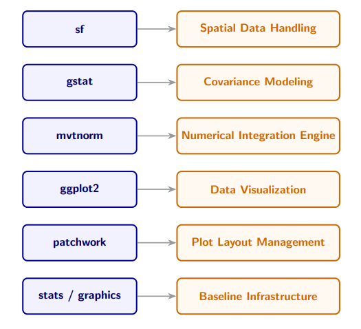

Figure 1: External R packages (left) and their architectural roles (right) in BMEmapping.

### 3.1 Operation

To use the BMEmapping package, users need R version 3.5 or higher. Its functions are organized into three categories: posterior density estimation, BME prediction, and model assessment. Two datasets `utsnowload` and `casnowload` are provided for demonstration purposes. The `utsnowload` dataset (Duah et al. 2025) consists of detrended, reliability-targeted design ground snow loads (RTSLs) specific to Utah, whereas the `casnowload` dataset (Bean et al. 2021) includes RTSLs data collected from sites across California. RTSLs are estimates of settled snow weight used in structural design to achieve a prescribed level of safety against snow-induced failure. Unlike simple maximum observed loads, RTSLs account for snow variability, extreme event probabilities, and uncertainty in available observations. Because snow loads vary spatially due to climate, terrain, and environmental factors, accurate estimation of RTSLs requires spatial interpolation methods that incorporate both spatial dependence and uncertainty.

### 3.2 Data cartography

Organizing and visualizing spatial data is a key step in spatial data analysis, as it reveals the underlying structure and spatial relationships present in geographic datasets. The bme_map function plays a central role in this process by organizing both hard and soft data into a structured format and generating `BMEmapping` objects—comprehensive containers that store all the necessary information for BME interpolation. By doing so, `bme_map` ensures that spatial predictions are built on well-organized, clearly defined input. A sample syntax to call the `bme_map` function is:

```r
bme_map(ch, cs, zh, a, b)
```

where the needed arguments are:

- `ch`: A two-column matrix or data frame containing the geographic coordinates of the hard data locations.
- `cs`: A two-column matrix or data frame containing the geographic coordinates of the soft data locations.
- `zh`: A vector containing observed hard data values at the locations specified in `ch`.
- `a`: A vector containing lower bounds of the soft-interval data at locations `cs`.
- `b`: A vector containing upper bounds of the soft-interval data at locations `cs`.